# MATH2349 Semester 2, 2018

## Additional Step: Machine Learning

```r
# If we know how many undergrad students we have, can you predict how many students will undertake post grad courses?
# Select data for ml
data <- edu_uni_tot2[2:3]

# Make task
task <- makeRegrTask(data = data, target = 'Post')
# Make learner
learner <- makeLearner('regr.glm')

# Fit model
n <- nrow(data)
training.set <- sample(n, size = 2*n/3)
test.set <- setdiff(1:n, training.set)

model <- mlr::train(learner, task, subset = training.set)

# Predict
pred <- predict(model, task = task, subset = test.set)

# Evaluate
performance(pred, measures = list(mse, mae))
```

```
##       mse       mae
## 87.510714  6.726035
```

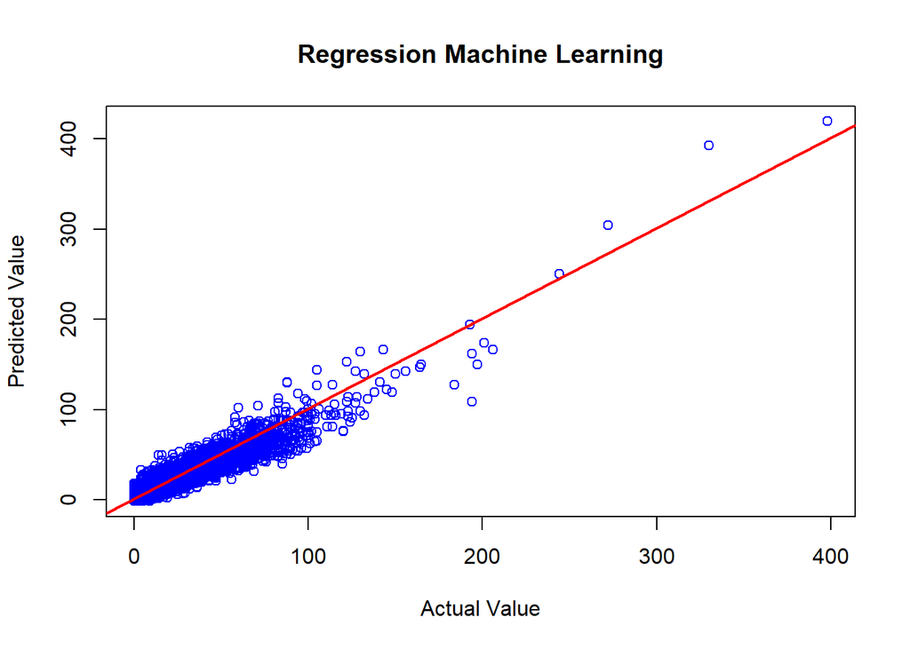

```r
x <- pred$data$truth
y <- pred$data$response
plot(x, y, xlab = 'Actual Value', ylab = 'Predicted Value', col = 'blue', main = 'Regression Machine Learning')
abline(1:500, 1:500, lwd = 2, col = 'red')
```

NOTE: Follow the order outlined above in the report. Make sure your code is visible (within the margin of the page). Do not use View() to show your data instead give headers (using head() )

Any further or optional pre-processing tasks can be added to the template using an additional section in the R Markdown file. Please also provide the R codes, outputs and brief explanations on why and how you applied these tasks on the data.